# Risk Factor Analysis

## Outcome Variable

**Outcome Variable:** haz

## Predictor Variables

**Intervention Variable:** fhtcm

**Adjustment Set:**

- arm
- W_mage
- W_fage
- meducyrs
- feducyrs
- W_mhtcm
- W_mwtkg
- W_mbmi
- single
- delta_W_mage
- delta_W_fage
- delta_meducyrs
- delta_feducyrs
- delta_W_mhtcm
- delta_W_mwtkg
- delta_W_mbmi
- delta_single

## Stratifying Variables

The analysis was stratified on these variable(s):

- agecat
- studyid
- country

## Data Summary

| agecat | studyid | country | fhtcm | n_cell | n |
| --- | --- | --- | --- | --- | --- |
| Birth | ki1000304b-SAS-CompFeed | INDIA | >=167 cm | 343 | 746 |
| Birth | ki1000304b-SAS-CompFeed | INDIA | <162 cm | 190 | 746 |
| Birth | ki1000304b-SAS-CompFeed | INDIA | [162-167) cm | 213 | 746 |
| Birth | ki1101329-Keneba | GAMBIA | >=167 cm | 3 | 7 |
| Birth | ki1101329-Keneba | GAMBIA | <162 cm | 1 | 7 |
| Birth | ki1101329-Keneba | GAMBIA | [162-167) cm | 3 | 7 |
| Birth | ki1119695-PROBIT | BELARUS | >=167 cm | 11740 | 12533 |
| Birth | ki1119695-PROBIT | BELARUS | <162 cm | 168 | 12533 |
| Birth | ki1119695-PROBIT | BELARUS | [162-167) cm | 625 | 12533 |
| Birth | ki1135781-COHORTS | GUATEMALA | >=167 cm | 29 | 206 |
| Birth | ki1135781-COHORTS | GUATEMALA | <162 cm | 121 | 206 |
| Birth | ki1135781-COHORTS | GUATEMALA | [162-167) cm | 56 | 206 |
| 6 months | ki1000304b-SAS-CompFeed | INDIA | >=167 cm | 369 | 807 |
| 6 months | ki1000304b-SAS-CompFeed | INDIA | <162 cm | 194 | 807 |
| 6 months | ki1000304b-SAS-CompFeed | INDIA | [162-167) cm | 244 | 807 |
| 6 months | ki1000304b-SAS-FoodSuppl | INDIA | >=167 cm | 102 | 372 |
| 6 months | ki1000304b-SAS-FoodSuppl | INDIA | <162 cm | 148 | 372 |
| 6 months | ki1000304b-SAS-FoodSuppl | INDIA | [162-167) cm | 122 | 372 |
| 6 months | ki1101329-Keneba | GAMBIA | >=167 cm | 979 | 1511 |
| 6 months | ki1101329-Keneba | GAMBIA | <162 cm | 113 | 1511 |
| 6 months | ki1101329-Keneba | GAMBIA | [162-167) cm | 419 | 1511 |
| 6 months | ki1119695-PROBIT | BELARUS | >=167 cm | 11146 | 11895 |
| 6 months | ki1119695-PROBIT | BELARUS | <162 cm | 156 | 11895 |
| 6 months | ki1119695-PROBIT | BELARUS | [162-167) cm | 593 | 11895 |
| 6 months | ki1135781-COHORTS | GUATEMALA | >=167 cm | 45 | 336 |
| 6 months | ki1135781-COHORTS | GUATEMALA | <162 cm | 197 | 336 |
| 6 months | ki1135781-COHORTS | GUATEMALA | [162-167) cm | 94 | 336 |
| 24 months | ki1101329-Keneba | GAMBIA | >=167 cm | 821 | 1297 |
| 24 months | ki1101329-Keneba | GAMBIA | <162 cm | 97 | 1297 |
| 24 months | ki1101329-Keneba | GAMBIA | [162-167) cm | 379 | 1297 |
| 24 months | ki1119695-PROBIT | BELARUS | >=167 cm | 3445 | 3670 |
| 24 months | ki1119695-PROBIT | BELARUS | <162 cm | 53 | 3670 |
| 24 months | ki1119695-PROBIT | BELARUS | [162-167) cm | 172 | 3670 |
| 24 months | ki1135781-COHORTS | GUATEMALA | >=167 cm | 70 | 526 |
| 24 months | ki1135781-COHORTS | GUATEMALA | <162 cm | 307 | 526 |
| 24 months | ki1135781-COHORTS | GUATEMALA | [162-167) cm | 149 | 526 |

The following strata were considered:

- agecat: 24 months, studyid: ki1101329-Keneba, country: GAMBIA
- agecat: 24 months, studyid: ki1119695-PROBIT, country: BELARUS
- agecat: 24 months, studyid: ki1135781-COHORTS, country: GUATEMALA
- agecat: 6 months, studyid: ki1000304b-SAS-CompFeed, country: INDIA
- agecat: 6 months, studyid: ki1000304b-SAS-FoodSuppl, country: INDIA
- agecat: 6 months, studyid: ki1101329-Keneba, country: GAMBIA
- agecat: 6 months, studyid: ki1119695-PROBIT, country: BELARUS
- agecat: 6 months, studyid: ki1135781-COHORTS, country: GUATEMALA
- agecat: Birth, studyid: ki1000304b-SAS-CompFeed, country: INDIA
- agecat: Birth, studyid: ki1101329-Keneba, country: GAMBIA
- agecat: Birth, studyid: ki1119695-PROBIT, country: BELARUS
- agecat: Birth, studyid: ki1135781-COHORTS, country: GUATEMALA

### Dropped Strata

Some strata were dropped due to rare outcomes:

- agecat: Birth, studyid: ki1101329-Keneba, country: GAMBIA

## Methods Detail

We’re interested in the causal parameters $E[Y_a]$ for all values of $a \in \mathcal{A}$. These parameters represent the mean outcome if, possibly contrary to fact, we intervened to set all units to have $A=a$. Under the randomization and positivity assumptions, these are identified by the statistical parameters $\psi_a=E_W[E_{Y|A,W}(Y|A=a,W)]$. In addition, we’re interested in the mean of $Y$, $E[Y]$ under no intervention (the observed mean). We will estimate these parameters by using SuperLearner to fit the relevant likelihood factors – $E_{Y|A,W}(Y|A=a,W)$ and $p(A=a|W)$, and then updating our likelihood fit using a joint TMLE.

For unadjusted analyses ($W=\{\}$), initial likelihoods were estimated using Lrnr_glm to estimate the simple $E(Y|A)$ and Lrnr_mean to estimate $p(A)$. For adjusted analyses, a small library containing Lrnr_glmnet, Lrnr_xgboost, and Lrnr_mean was used.

Having estimated these parameters, we will then use the delta method to estimate relative risks and attributable risks relative to a prespecified baseline level of $A$.

# Results Detail

## Results Plots

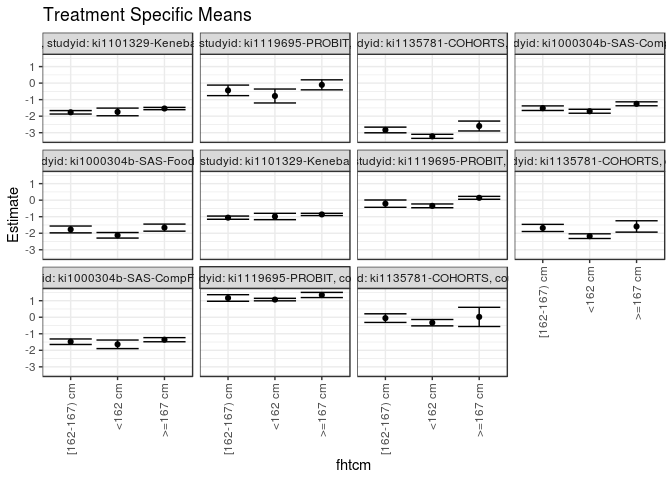

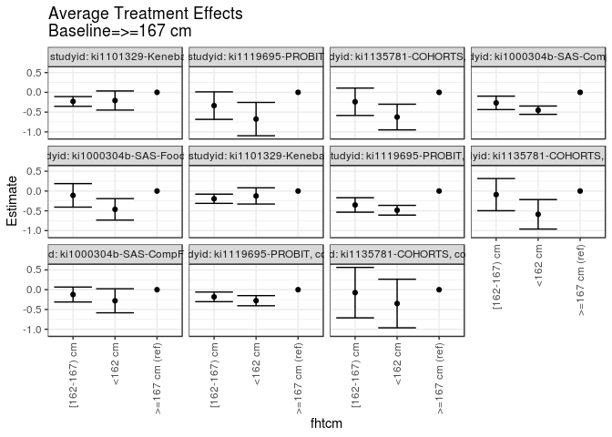

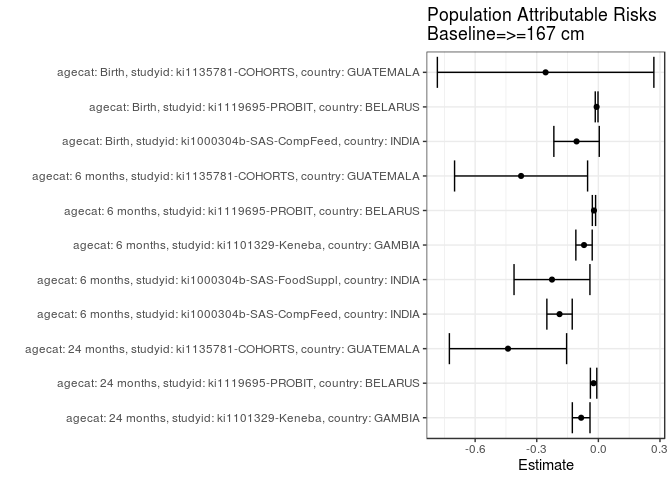

## Results Table

### Parameter: TSM

| agecat | studyid | country | intervention_level | baseline_level | estimate | ci_lower | ci_upper |
| --- | --- | --- | --- | --- | --- | --- | --- |
| Birth | ki1000304b-SAS-CompFeed | INDIA | >=167 cm | NA | -1.3589035 | -1.4845687 | -1.2332383 |
| Birth | ki1000304b-SAS-CompFeed | INDIA | <162 cm | NA | -1.6385744 | -1.8971294 | -1.3800195 |
| Birth | ki1000304b-SAS-CompFeed | INDIA | [162-167) cm | NA | -1.4809829 | -1.6471320 | -1.3148339 |
| Birth | ki1119695-PROBIT | BELARUS | >=167 cm | NA | 1.3452160 | 1.1890311 | 1.5014009 |
| Birth | ki1119695-PROBIT | BELARUS | <162 cm | NA | 1.0672837 | 0.9912906 | 1.1432767 |
| Birth | ki1119695-PROBIT | BELARUS | [162-167) cm | NA | 1.1643972 | 0.9649630 | 1.3638314 |
| Birth | ki1135781-COHORTS | GUATEMALA | >=167 cm | NA | 0.0201003 | -0.5611643 | 0.6013649 |
| Birth | ki1135781-COHORTS | GUATEMALA | <162 cm | NA | -0.3290992 | -0.5220339 | -0.1361645 |
| Birth | ki1135781-COHORTS | GUATEMALA | [162-167) cm | NA | -0.0536713 | -0.3143707 | 0.2070281 |
| 6 months | ki1000304b-SAS-CompFeed | INDIA | >=167 cm | NA | -1.2510708 | -1.3705294 | -1.1316121 |
| 6 months | ki1000304b-SAS-CompFeed | INDIA | <162 cm | NA | -1.7019419 | -1.8228618 | -1.5810220 |
| 6 months | ki1000304b-SAS-CompFeed | INDIA | [162-167) cm | NA | -1.5167927 | -1.6549390 | -1.3786464 |
| 6 months | ki1000304b-SAS-FoodSuppl | INDIA | >=167 cm | NA | -1.6613108 | -1.8747257 | -1.4478958 |
| 6 months | ki1000304b-SAS-FoodSuppl | INDIA | <162 cm | NA | -2.1247193 | -2.2923649 | -1.9570736 |
| 6 months | ki1000304b-SAS-FoodSuppl | INDIA | [162-167) cm | NA | -1.7708330 | -1.9772432 | -1.5644228 |
| 6 months | ki1101329-Keneba | GAMBIA | >=167 cm | NA | -0.8623495 | -0.9303900 | -0.7943090 |
| 6 months | ki1101329-Keneba | GAMBIA | <162 cm | NA | -0.9861659 | -1.1795628 | -0.7927689 |
| 6 months | ki1101329-Keneba | GAMBIA | [162-167) cm | NA | -1.0576457 | -1.1544690 | -0.9608224 |
| 6 months | ki1119695-PROBIT | BELARUS | >=167 cm | NA | 0.1418340 | 0.0542652 | 0.2294027 |
| 6 months | ki1119695-PROBIT | BELARUS | <162 cm | NA | -0.3435754 | -0.4570750 | -0.2300757 |
| 6 months | ki1119695-PROBIT | BELARUS | [162-167) cm | NA | -0.2104246 | -0.4318001 | 0.0109510 |
| 6 months | ki1135781-COHORTS | GUATEMALA | >=167 cm | NA | -1.5889819 | -1.9329538 | -1.2450099 |
| 6 months | ki1135781-COHORTS | GUATEMALA | <162 cm | NA | -2.1774812 | -2.3186252 | -2.0363372 |
| 6 months | ki1135781-COHORTS | GUATEMALA | [162-167) cm | NA | -1.6802690 | -1.8958127 | -1.4647253 |
| 24 months | ki1101329-Keneba | GAMBIA | >=167 cm | NA | -1.5363580 | -1.6061059 | -1.4666101 |
| 24 months | ki1101329-Keneba | GAMBIA | <162 cm | NA | -1.7429744 | -1.9740264 | -1.5119224 |
| 24 months | ki1101329-Keneba | GAMBIA | [162-167) cm | NA | -1.7658936 | -1.8693138 | -1.6624733 |
| 24 months | ki1119695-PROBIT | BELARUS | >=167 cm | NA | -0.1034201 | -0.4065772 | 0.1997369 |
| 24 months | ki1119695-PROBIT | BELARUS | <162 cm | NA | -0.7786967 | -1.1993489 | -0.3580445 |
| 24 months | ki1119695-PROBIT | BELARUS | [162-167) cm | NA | -0.4390119 | -0.7578903 | -0.1201334 |
| 24 months | ki1135781-COHORTS | GUATEMALA | >=167 cm | NA | -2.5947527 | -2.8942781 | -2.2952273 |
| 24 months | ki1135781-COHORTS | GUATEMALA | <162 cm | NA | -3.2189021 | -3.3414641 | -3.0963401 |
| 24 months | ki1135781-COHORTS | GUATEMALA | [162-167) cm | NA | -2.8334422 | -3.0047483 | -2.6621362 |

### Parameter: E(Y)

| agecat | studyid | country | intervention_level | baseline_level | estimate | ci_lower | ci_upper |
| --- | --- | --- | --- | --- | --- | --- | --- |
| Birth | ki1000304b-SAS-CompFeed | INDIA | NA | NA | -1.4650804 | -1.5752607 | -1.3549001 |
| Birth | ki1119695-PROBIT | BELARUS | NA | NA | 1.3367673 | 1.1803545 | 1.4931801 |
| Birth | ki1135781-COHORTS | GUATEMALA | NA | NA | -0.2367476 | -0.3941046 | -0.0793906 |
| 6 months | ki1000304b-SAS-CompFeed | INDIA | NA | NA | -1.4400743 | -1.5370187 | -1.3431300 |
| 6 months | ki1000304b-SAS-FoodSuppl | INDIA | NA | NA | -1.8871505 | -1.9993302 | -1.7749709 |
| 6 months | ki1101329-Keneba | GAMBIA | NA | NA | -0.9321551 | -0.9872314 | -0.8770788 |
| 6 months | ki1119695-PROBIT | BELARUS | NA | NA | 0.1203779 | 0.0296502 | 0.2111056 |
| 6 months | ki1135781-COHORTS | GUATEMALA | NA | NA | -1.9652976 | -2.0794998 | -1.8510954 |
| 24 months | ki1101329-Keneba | GAMBIA | NA | NA | -1.6200950 | -1.6766111 | -1.5635788 |
| 24 months | ki1119695-PROBIT | BELARUS | NA | NA | -0.1266303 | -0.4286611 | 0.1754004 |
| 24 months | ki1135781-COHORTS | GUATEMALA | NA | NA | -3.0347529 | -3.1289563 | -2.9405494 |

### Parameter: ATE

| agecat | studyid | country | intervention_level | baseline_level | estimate | ci_lower | ci_upper |
| --- | --- | --- | --- | --- | --- | --- | --- |
| Birth | ki1000304b-SAS-CompFeed | INDIA | >=167 cm | >=167 cm | 0.0000000 | 0.0000000 | 0.0000000 |
| Birth | ki1000304b-SAS-CompFeed | INDIA | <162 cm | >=167 cm | -0.2796709 | -0.5834821 | 0.0241403 |
| Birth | ki1000304b-SAS-CompFeed | INDIA | [162-167) cm | >=167 cm | -0.1220794 | -0.3109562 | 0.0667974 |
| Birth | ki1119695-PROBIT | BELARUS | >=167 cm | >=167 cm | 0.0000000 | 0.0000000 | 0.0000000 |
| Birth | ki1119695-PROBIT | BELARUS | <162 cm | >=167 cm | -0.2779324 | -0.4060010 | -0.1498637 |
| Birth | ki1119695-PROBIT | BELARUS | [162-167) cm | >=167 cm | -0.1808188 | -0.3029324 | -0.0587052 |
| Birth | ki1135781-COHORTS | GUATEMALA | >=167 cm | >=167 cm | 0.0000000 | 0.0000000 | 0.0000000 |
| Birth | ki1135781-COHORTS | GUATEMALA | <162 cm | >=167 cm | -0.3491996 | -0.9628879 | 0.2644888 |
| Birth | ki1135781-COHORTS | GUATEMALA | [162-167) cm | >=167 cm | -0.0737716 | -0.7114772 | 0.5639340 |
| 6 months | ki1000304b-SAS-CompFeed | INDIA | >=167 cm | >=167 cm | 0.0000000 | 0.0000000 | 0.0000000 |
| 6 months | ki1000304b-SAS-CompFeed | INDIA | <162 cm | >=167 cm | -0.4508712 | -0.5559092 | -0.3458332 |
| 6 months | ki1000304b-SAS-CompFeed | INDIA | [162-167) cm | >=167 cm | -0.2657219 | -0.4354423 | -0.0960015 |
| 6 months | ki1000304b-SAS-FoodSuppl | INDIA | >=167 cm | >=167 cm | 0.0000000 | 0.0000000 | 0.0000000 |
| 6 months | ki1000304b-SAS-FoodSuppl | INDIA | <162 cm | >=167 cm | -0.4634085 | -0.7350913 | -0.1917257 |
| 6 months | ki1000304b-SAS-FoodSuppl | INDIA | [162-167) cm | >=167 cm | -0.1095222 | -0.4065281 | 0.1874836 |
| 6 months | ki1101329-Keneba | GAMBIA | >=167 cm | >=167 cm | 0.0000000 | 0.0000000 | 0.0000000 |
| 6 months | ki1101329-Keneba | GAMBIA | <162 cm | >=167 cm | -0.1238164 | -0.3282282 | 0.0805955 |
| 6 months | ki1101329-Keneba | GAMBIA | [162-167) cm | >=167 cm | -0.1952962 | -0.3114603 | -0.0791321 |
| 6 months | ki1119695-PROBIT | BELARUS | >=167 cm | >=167 cm | 0.0000000 | 0.0000000 | 0.0000000 |
| 6 months | ki1119695-PROBIT | BELARUS | <162 cm | >=167 cm | -0.4854093 | -0.6086731 | -0.3621456 |
| 6 months | ki1119695-PROBIT | BELARUS | [162-167) cm | >=167 cm | -0.3522585 | -0.5347403 | -0.1697768 |
| 6 months | ki1135781-COHORTS | GUATEMALA | >=167 cm | >=167 cm | 0.0000000 | 0.0000000 | 0.0000000 |
| 6 months | ki1135781-COHORTS | GUATEMALA | <162 cm | >=167 cm | -0.5884994 | -0.9613245 | -0.2156742 |
| 6 months | ki1135781-COHORTS | GUATEMALA | [162-167) cm | >=167 cm | -0.0912871 | -0.4981173 | 0.3155431 |
| 24 months | ki1101329-Keneba | GAMBIA | >=167 cm | >=167 cm | 0.0000000 | 0.0000000 | 0.0000000 |
| 24 months | ki1101329-Keneba | GAMBIA | <162 cm | >=167 cm | -0.2066164 | -0.4475668 | 0.0343340 |
| 24 months | ki1101329-Keneba | GAMBIA | [162-167) cm | >=167 cm | -0.2295356 | -0.3522876 | -0.1067835 |
| 24 months | ki1119695-PROBIT | BELARUS | >=167 cm | >=167 cm | 0.0000000 | 0.0000000 | 0.0000000 |
| 24 months | ki1119695-PROBIT | BELARUS | <162 cm | >=167 cm | -0.6752766 | -1.0961962 | -0.2543570 |
| 24 months | ki1119695-PROBIT | BELARUS | [162-167) cm | >=167 cm | -0.3355917 | -0.6830160 | 0.0118326 |
| 24 months | ki1135781-COHORTS | GUATEMALA | >=167 cm | >=167 cm | 0.0000000 | 0.0000000 | 0.0000000 |
| 24 months | ki1135781-COHORTS | GUATEMALA | <162 cm | >=167 cm | -0.6241494 | -0.9486961 | -0.2996027 |
| 24 months | ki1135781-COHORTS | GUATEMALA | [162-167) cm | >=167 cm | -0.2386895 | -0.5845521 | 0.1071730 |

### Parameter: PAR

| agecat | studyid | country | intervention_level | baseline_level | estimate | ci_lower | ci_upper |
| --- | --- | --- | --- | --- | --- | --- | --- |
| Birth | ki1000304b-SAS-CompFeed | INDIA | >=167 cm | NA | -0.1061769 | -0.2167133 | 0.0043595 |
| Birth | ki1119695-PROBIT | BELARUS | >=167 cm | NA | -0.0084487 | -0.0151361 | -0.0017613 |
| Birth | ki1135781-COHORTS | GUATEMALA | >=167 cm | NA | -0.2568479 | -0.7839501 | 0.2702544 |
| 6 months | ki1000304b-SAS-CompFeed | INDIA | >=167 cm | NA | -0.1890036 | -0.2507407 | -0.1272664 |
| 6 months | ki1000304b-SAS-FoodSuppl | INDIA | >=167 cm | NA | -0.2258398 | -0.4106066 | -0.0410730 |
| 6 months | ki1101329-Keneba | GAMBIA | >=167 cm | NA | -0.0698056 | -0.1096190 | -0.0299922 |
| 6 months | ki1119695-PROBIT | BELARUS | >=167 cm | NA | -0.0214561 | -0.0293638 | -0.0135484 |
| 6 months | ki1135781-COHORTS | GUATEMALA | >=167 cm | NA | -0.3763158 | -0.7001650 | -0.0524665 |
| 24 months | ki1101329-Keneba | GAMBIA | >=167 cm | NA | -0.0837370 | -0.1267558 | -0.0407181 |
| 24 months | ki1119695-PROBIT | BELARUS | >=167 cm | NA | -0.0232102 | -0.0387983 | -0.0076221 |
| 24 months | ki1135781-COHORTS | GUATEMALA | >=167 cm | NA | -0.4400001 | -0.7254088 | -0.1545914 |